# Course Project Reproducible Research

Icaro Oliveira

Saturday, September 13, 2014

```r
library(data.table)
unzip(zipfile="repdata-data-activity.zip")
data<-fread('activity.csv')
data$date<-as.factor(data$date)
```

**What is mean total number of steps taken per day?**

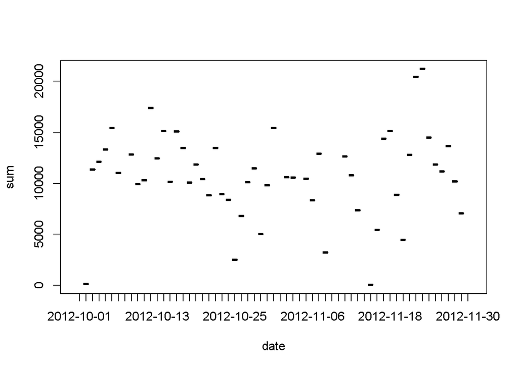

```r
data2 <- na.omit(data)
total.steps.by.date<-data2[,sum(steps),by=date]
plot(total.steps.by.date,type='h',xlab='date',ylab='sum')
```

```r
mean.steps.by.date<-data2[,mean(steps),by=date]
setnames(mean.steps.by.date,c('date','mean'))
mean.steps.by.date
```

```
##           date    mean
##  1: 2012-10-02  0.4375
##  2: 2012-10-03 39.4167
##  3: 2012-10-04 42.0694
##  4: 2012-10-05 46.1597
##  5: 2012-10-06 53.5417
##  6: 2012-10-07 38.2465
##  7: 2012-10-09 44.4826
##  8: 2012-10-10 34.3750
##  9: 2012-10-11 35.7778
## 10: 2012-10-12 60.3542
## 11: 2012-10-13 43.1458
## 12: 2012-10-14 52.4236
## 13: 2012-10-15 35.2049
## 14: 2012-10-16 52.3750
```

[output cut: 40 more lines]

```r
median.steps.by.date<-data2[,median(steps),by=date]
setnames(median.steps.by.date,c('date','median'))
median.steps.by.date
```

```
##           date median
##  1: 2012-10-02      0
##  2: 2012-10-03      0
##  3: 2012-10-04      0
##  4: 2012-10-05      0
##  5: 2012-10-06      0
##  6: 2012-10-07      0
##  7: 2012-10-09      0
##  8: 2012-10-10      0
##  9: 2012-10-11      0
## 10: 2012-10-12      0
## 11: 2012-10-13      0
## 12: 2012-10-14      0
## 13: 2012-10-15      0
## 14: 2012-10-16      0
```

[output cut: 40 more lines]

**What is the average daily activity pattern?**

A time series plot of the 5-minute interval (x-axis) and the average number of steps taken from averaged across all days (y-axis):

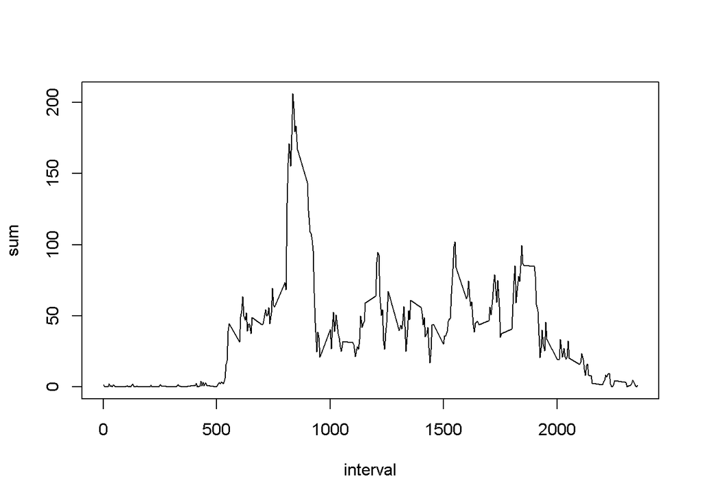

```r
steps.by.interval<-data2[,mean(steps),by=interval]
plot(steps.by.interval,type='l',xlab='interval',ylab='sum')
```

```r
steps.by.interval[max(V1),interval]
```

```
## [1] 1705
```

**Imputing missing values**

Total number of missing values in the dataset:

```r
sum(is.na(data))
```

```
## [1] 2304
```

The strategy for filling in all of the missing values in the dataset is set zero in NA column. The new dataset is the data2.

```r
data2<-data
set(data2,which(is.na(data2)),1,0)
```

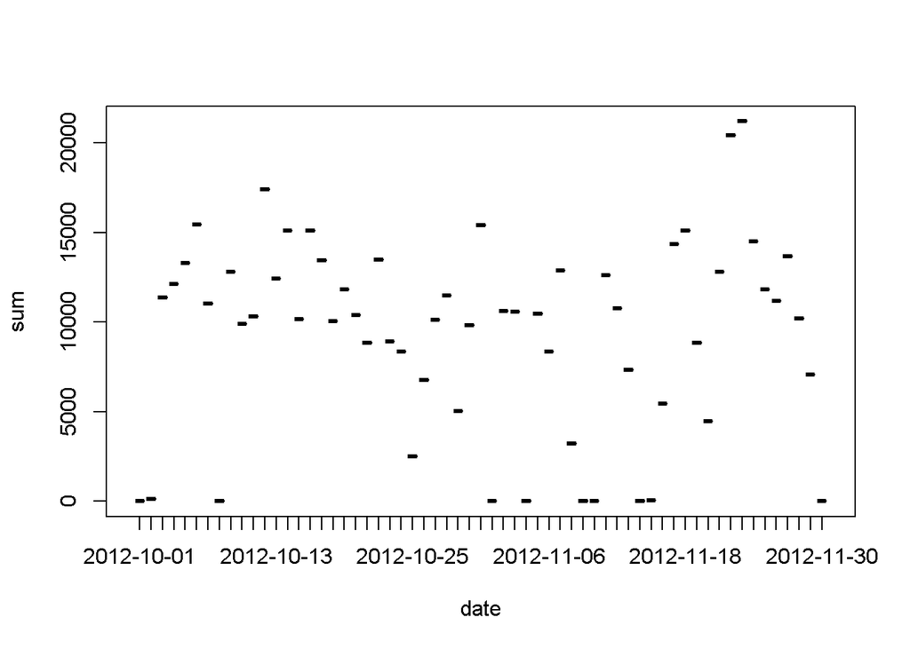

```r
total.steps.by.date<-data2[,sum(steps),by=date]
plot(total.steps.by.date,type='h',xlab='date',ylab='sum')
```

```r
mean.steps.by.date<-data2[,mean(steps),by=date]
setnames(mean.steps.by.date,c('date','mean'))
mean.steps.by.date
```

```
##           date    mean
##  1: 2012-10-01  0.0000
##  2: 2012-10-02  0.4375
##  3: 2012-10-03 39.4167
##  4: 2012-10-04 42.0694
##  5: 2012-10-05 46.1597
##  6: 2012-10-06 53.5417
##  7: 2012-10-07 38.2465
##  8: 2012-10-08  0.0000
##  9: 2012-10-09 44.4826
## 10: 2012-10-10 34.3750
## 11: 2012-10-11 35.7778
## 12: 2012-10-12 60.3542
## 13: 2012-10-13 43.1458
## 14: 2012-10-14 52.4236
```

[output cut: 48 more lines]

```r
median.steps.by.date<-data2[,median(steps),by=date]
setnames(median.steps.by.date,c('date','median'))
median.steps.by.date
```

```
##           date median
##  1: 2012-10-01      0
##  2: 2012-10-02      0
##  3: 2012-10-03      0
##  4: 2012-10-04      0
##  5: 2012-10-05      0
##  6: 2012-10-06      0
##  7: 2012-10-07      0
##  8: 2012-10-08      0
##  9: 2012-10-09      0
## 10: 2012-10-10      0
## 11: 2012-10-11      0
## 12: 2012-10-12      0
## 13: 2012-10-13      0
## 14: 2012-10-14      0
```

[output cut: 48 more lines]

These values differ from the estimates of the first part of the assignment and the impact is high, because some new dates are showed like 2012-10-01, 2012-10-08, 2012-11-04 and others with means and medians next to zero.

**Are there differences in activity patterns between weekdays and weekends?**

```r
discoverTypeDay = function(dates)
{
    week.days<-c("Monday", "Tuesday", "Wednesday", "Thursday", "Friday")
    week.end<-c("Saturday", "Sunday")
    type.day <- vector()
    for (d in dates)
    {
      day = weekdays(as.Date(d))
      if (day %in% week.days)
        type.day<-rbind(type.day,"weekday")
      else if (day %in% week.end)
        type.day<-rbind(type.day,"weekend")
      else
          stop("invalid date")
    }
    return (type.day)
}

data2<-data2[,"type.day":=discoverTypeDay(date),by=steps]
data2$type.day<-as.factor(data2$type.day)

data2<-data2[,mean(steps),by="interval,type.day"]
```

A panel plot containing a time series plot of the 5-minute interval and the average number of steps taken from all weekday days or weekend days (y-axis).

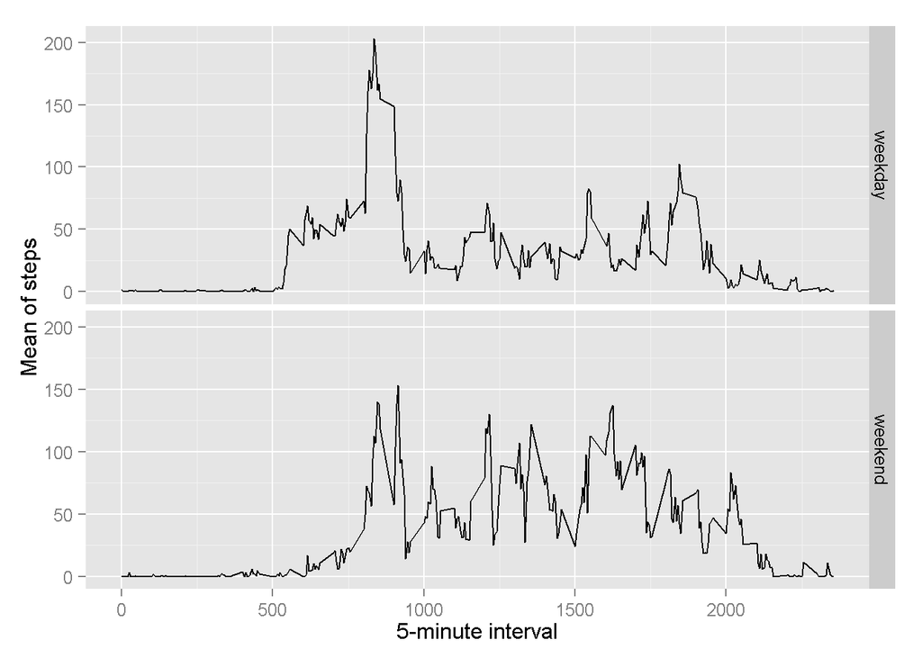

```r
library(ggplot2)
ggplot(data2, aes(interval, V1)) + geom_line() + facet_grid(type.day ~ .) +
    xlab("5-minute interval") + ylab("Mean of steps")
```